title: “Project 3b - Data Analysis and Visualizations”

author: “Sufian”

date: “10/16/2019”

output: html_document

Rpub links:

http://rpubs.com/ssufian/540742

```r
# Load packages
library(rvest)
library(stringr)
library(dplyr)
library(ggplot2)
library(tidyverse)
library(xml2)
library(httr)
library("tm")
library("SnowballC")
library("wordcloud")
library("RColorBrewer")
library(tidytext)
library("magrittr")
require(ggthemes)
library('sentimentr')
```

## Reading each teammates’ job site scrapped job listings

```r
#read from Leticia
ltcancel<-read.csv("https://raw.githubusercontent.com/ltcancel/Project3/master/SimplyHiredJobs.csv",stringsAsFactors = FALSE)
colnames(ltcancel)<-c("Position", "Company","Location","Salary","URL","Job_Description")
#read from Salma
selshahawy<-read.csv("https://raw.githubusercontent.com/salma71/MSDS_2019/master/Fall2019/aquisition_management_607/project_3/jobs_detailsInfo.csv", stringsAsFactors = FALSE)
colnames(selshahawy)<-c("Position", "Company","Location","URL","Job_Description")
#read from Sufian
ssufian<-read.csv("https://raw.githubusercontent.com/Luz917/data607project3_ssufian_monster_jobs/master/monsterjobs.csv", stringsAsFactors = FALSE)
colnames(ssufian)<-c("Position", "Company","Location","Salary","URL","Job_Description")
```

### Merging all scrapped files into one

```r
twocsv<-merge(ltcancel,selshahawy,all= TRUE)
allcsv<-merge(twocsv,ssufian, all=TRUE)
```

### Deleting unnecessary columns

```r
library("magrittr")
# REmove Salary column
clean_allcsv <- allcsv[,-c(4,6)]
```

### TF-IDF Analysis

TF-IDF (term frequency-inverse document frequency) is a metric that represents how ‘important’ a word is to a

document in the document set. It works by increasing proportionally to the number of times a word appears in a

document, but is offset by the number of documents that contain the word. So, words that are common in every

document, such as “this”, “what”, “and” “if”, rank low even though they may appear many times, since they don’t

mean much to that document in particular.

- Creating a list of how to remove and streamline the corpus: removing stopwords, lower case for simplicity

and removing punctuations

```r
#tfidf <- clean_allcsv1
tfidf <- clean_allcsv
# Control list to be used for all corpuses
control_list <- list(removePunctuation = TRUE, stopwords = TRUE, tolower = TRUE,
                     weighting = weightTfIdf)
colnames(tfidf)
```

```
## [1] "Position"        "Company"         "Location"        "Job_Description"
```

### Text Mining (tm) Package

2. In this exercise, we load the data as txt file, i.e., tfidf$Job_Description as a corpus.
3. We then build a term-document matrix which is a Document matrix of table containing the frequency of the

words. Column names are words and row names are documents. The function TermDocumentMatrix() from text mining

package is the constructor

4. Notice we passed in the argument of our control list

```r
# TF-IDF Based on the 3 job postings
corpus.all <- VCorpus(VectorSource(tfidf$Job_Description))
dtm.all <- DocumentTermMatrix(corpus.all,control = control_list)
dtm.all
```

```
## <<DocumentTermMatrix (documents: 295, terms: 12174)>>
## Non-/sparse entries: 72185/3519145
## Sparsity           : 98%
## Maximal term length: 259
## Weighting          : term frequency - inverse document frequency (normalized) (tf-idf)
```

### Inspecting the Term Document Matrix

- You will see that there’s great amount of sparsity
- You will also observe that its using the tf-idf factors to normalize the words

```r
tdm.all <- TermDocumentMatrix(corpus.all,control = control_list)
inspect(tdm.all)
```

```
## <<TermDocumentMatrix (terms: 12174, documents: 295)>>
## Non-/sparse entries: 72185/3519145
## Sparsity           : 98%
## Maximal term length: 259
## Weighting          : term frequency - inverse document frequency (normalized) (tf-idf)
## Sample             :
##            Docs
## Terms                10         177           18         182        215
##   analysis  0.000000000 0.004294435 0.0000000000 0.000000000 0.00000000
##   analytics 0.000000000 0.000000000 0.0000000000 0.004038535 0.00000000
##   business  0.002660829 0.000000000 0.0000000000 0.000000000 0.00000000
##   clinical  0.000000000 0.000000000 0.0350732998 0.000000000 0.00000000
##   learning  0.000000000 0.001436932 0.0000000000 0.000000000 0.02436643
##   machine   0.000000000 0.001743389 0.0000000000 0.000000000 0.01478156
##   models    0.000000000 0.000000000 0.0000000000 0.000000000 0.00000000
##   product   0.000000000 0.000000000 0.0035104073 0.005318363 0.00000000
##   research  0.000000000 0.000000000 0.0009696016 0.000000000 0.01378575
##   status    0.017671845 0.000000000 0.0053753855 0.000000000 0.00000000
##            Docs
## Terms               237        241          53          67          89
##   analysis  0.000000000 0.00000000 0.000000000 0.007395971 0.000000000
##   analytics 0.000000000 0.00000000 0.000000000 0.000000000 0.005066337
##   business  0.000000000 0.03116619 0.000000000 0.004674928 0.000000000
##   clinical  0.000000000 0.00000000 0.000000000 0.000000000 0.000000000
##   learning  0.010853574 0.00000000 0.000000000 0.009898862 0.003664360
##   machine   0.008778895 0.00000000 0.000000000 0.012010016 0.004445867
##   models    0.002476529 0.00000000 0.000000000 0.000000000 0.000000000
##   product   0.003293605 0.00000000 0.011905326 0.000000000 0.000000000
##   research  0.024562419 0.00000000 0.000000000 0.000000000 0.002764237
##   status    0.007565105 0.00000000 0.004557571 0.000000000 0.000000000
```

### Dealing with Sparcity

- Term-document matrices tend to get very big already for normal sized data sets. Therefore we remove sparse

terms, i.e., terms occurring only in very few documents. And this reduces the matrix dramatically without losing

signiﬁcant relations inherent to the matrix

- In our case, we removed about 60% of sparcity (i.e., terms occurring 0 times or outlier in a document) elements.
- What percentage to utilized is a matter of trial and errors, we played with ranges between 0.4 to 0.8 and

finally settled to 0.6 to get a “good” balance

```r
# Remove outliers consisting of very rare terms - infrequent words outlairs
tdms.60 <- removeSparseTerms(tdm.all, sparse = 0.60)
inspect(tdms.60)
```

```
## <<TermDocumentMatrix (terms: 57, documents: 295)>>
## Non-/sparse entries: 8848/7967
## Sparsity           : 47%
## Maximal term length: 16
## Weighting          : term frequency - inverse document frequency (normalized) (tf-idf)
## Sample             :
##              Docs
## Terms                 124         125         157         158          19
##   analysis    0.012578974 0.012578974 0.013396475 0.013396475 0.009383434
##   analytics   0.000000000 0.000000000 0.000000000 0.000000000 0.030386865
##   business    0.013251765 0.013251765 0.004233897 0.004233897 0.017793560
##   learning    0.014029883 0.014029883 0.000000000 0.000000000 0.000000000
##   machine     0.013617656 0.013617656 0.000000000 0.000000000 0.000000000
##   models      0.015366180 0.015366180 0.000000000 0.000000000 0.004298469
##   product     0.005108979 0.005108979 0.048969077 0.048969077 0.000000000
##   research    0.000000000 0.000000000 0.000000000 0.000000000 0.004736952
##   solutions   0.018969624 0.018969624 0.000000000 0.000000000 0.015919442
##   statistical 0.008796128 0.008796128 0.007025838 0.007025838 0.000000000
##              Docs
## Terms                  20         250         261          47          9
##   analysis    0.009383434 0.000000000 0.010812384 0.018051183 0.00000000
##   analytics   0.030386865 0.006236725 0.007503066 0.008350870 0.00000000
##   business    0.017793560 0.004260694 0.010251620 0.000000000 0.00000000
##   learning    0.000000000 0.013532621 0.009044645 0.012079967 0.00000000
##   machine     0.000000000 0.010945837 0.006584171 0.014656291 0.00000000
##   models      0.004298469 0.006175648 0.017335703 0.008269089 0.00000000
##   product     0.000000000 0.016426336 0.006587211 0.000000000 0.00000000
##   research    0.004736952 0.000000000 0.005458315 0.009112611 0.00000000
##   solutions   0.015919442 0.000000000 0.012229149 0.000000000 0.00000000
##   statistical 0.000000000 0.014140611 0.014176501 0.018934039 0.07447389
```

```r
# explore the data
# The data reduction techniques used singular value decomposition reduces the number of columns (documents) but keeps the number of rows (words).
count <- rowSums(as.matrix(tdms.60))

count <- sort(rowSums(as.matrix(tdms.60)), decreasing=TRUE)
head(count, 14)
```

```
##    learning     machine    business   analytics    research     product
##   1.5722981   1.4356709   1.2601209   1.2161202   1.2009078   1.1304082
##      models    analysis   solutions statistical  technology     company
##   1.0540340   1.0122697   0.9753109   0.9747207   0.9022690   0.8991435
## development  management
##   0.8952993   0.8818323
```

```r
df_all <- data.frame(words=names(count), count=count)
head(df_all)
```

```
##               words    count
## learning   learning 1.572298
## machine     machine 1.435671
## business   business 1.260121
## analytics analytics 1.216120
## research   research 1.200908
## product     product 1.130408
```

### Setting up TF-IDF graph

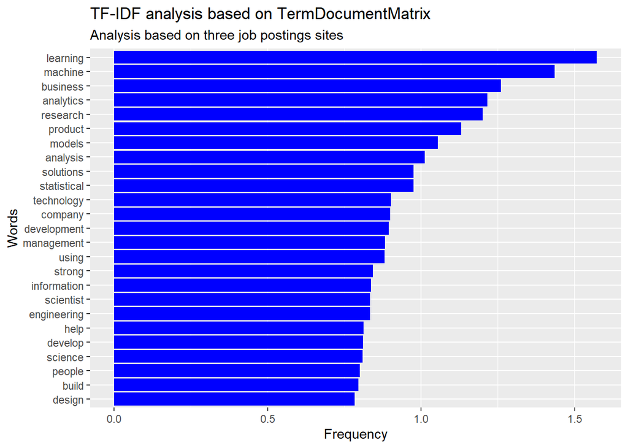

```r
# Graph of TF-IDF in the 3 job postings
ggplot(head(df_all,25), aes(reorder(words, count), count)) +  # head because I desc the order
  geom_bar(stat = "identity", fill = "blue") +
  labs(title = "TF-IDF analysis based on TermDocumentMatrix",
       subtitle = "Analysis based on three job postings sites",
       x = "Words", y = "Frequency") +
  coord_flip()
```

Observation 1a:

Through the TF-IDF process, words such as machine, learning, business, analytics, research, statistics and the

likes were found to be top of the importance list. Not surprisingly, these are the buzz words of today that are

associated with the data scientist roles.

### Generate the Word cloud

The important key skill sets can be illustrated in a word cloud as follow

```r
## here we wanted to plot word cloud to get the most used words regarding to TDF
word_cloud <- tm_map(corpus.all, removeWords, c("services", "data", "andor", "ability", "using", "new", "science", "scientist" , "you", "must", "will", "including", "can", stopwords('english')))
```

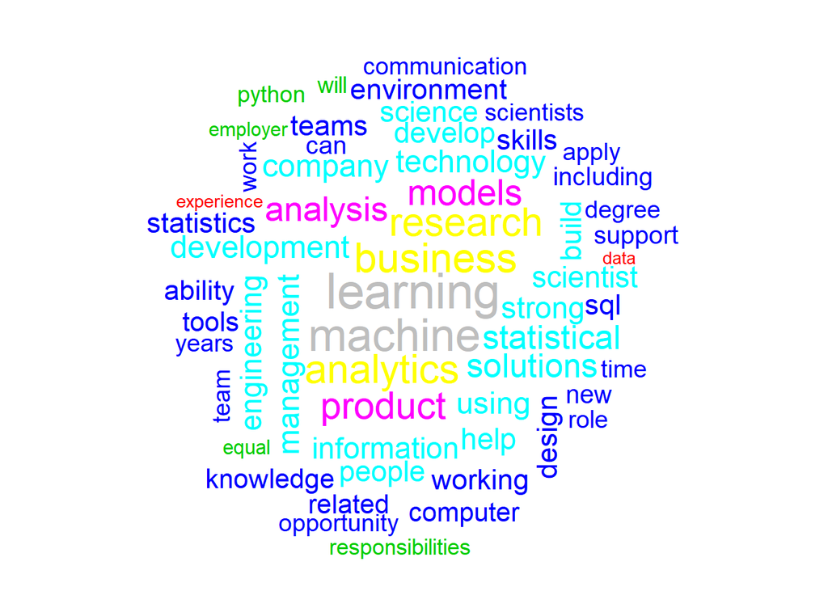

```r
wordcloud(names(count),
          count,
          max.words = 80,
          random.order = FALSE,
          scale=c(2.5,.4),
          random.color = FALSE,
          colors=palette())
```

Observation 1b:

Another graphical way to show importance of words is through the word cloud and again to no one’s surprise words

like machine, learning, models, analytics came out glaringly clear against the other buzz words.

### Explore frequent terms and their associations

### Frequency of words in Job Listings

Our goal was to find the most valued data science skills using a frequency-of-occurance approach. We created new

variables for analyzing three types of skills (hard skills, soft skills, and tool skills) most commonly associated

with the data scientist role within the job summaries as advertised in the various job web sites.

### Frequency of Technical Skills

- Technical tool Skills:

We used the mutate function to create new variables for the tool skills category and preserve existing variables

from the summary column, and turned on case insensitivity.

```r
toolskills <- clean_allcsv %>%
    mutate(R = grepl("\\bR\\b,", Job_Description, ignore.case=TRUE)) %>%
    mutate(python = grepl("Python", Job_Description, ignore.case=TRUE)) %>%
    mutate(SQL = grepl("SQL", Job_Description, ignore.case=TRUE)) %>%
    mutate(hadoop = grepl("hadoop", Job_Description, ignore.case=TRUE)) %>%
    mutate(perl = grepl("perl", Job_Description, ignore.case=TRUE)) %>%
    mutate(matplotlib = grepl("matplotlib", Job_Description, ignore.case=TRUE)) %>%
    mutate(Cplusplus = grepl("C++", Job_Description, fixed=TRUE)) %>%
    mutate(VB = grepl("VB", Job_Description, ignore.case=TRUE)) %>%
    mutate(java = grepl("java\\b", Job_Description, ignore.case=TRUE)) %>%
    mutate(scala = grepl("scala", Job_Description, ignore.case=TRUE)) %>%
    mutate(tensorflow = grepl("tensorflow",Job_Description, ignore.case=TRUE)) %>%
    mutate(javascript = grepl("javascript", Job_Description, ignore.case=TRUE)) %>%
    mutate(spark = grepl("spark", Job_Description, ignore.case=TRUE)) %>%
    mutate(java = grepl("java", Job_Description, ignore.case=TRUE)) %>%
    select(
      Position,
      Company,
      R,
      python,
      SQL,
      hadoop,
      perl,
      matplotlib,
      Cplusplus,
      VB,
      java,
      scala,
      tensorflow,
      javascript,
      spark,
      java)
```

### Setup tool skills for plotting

```r
toolskills2 <- toolskills %>% select(-(1:2)) %>% summarise_all(sum) %>% gather(variable,value) %>% arrange(desc(value))
```

### Visualized the most in-demand technical on-the-job tool sKills:

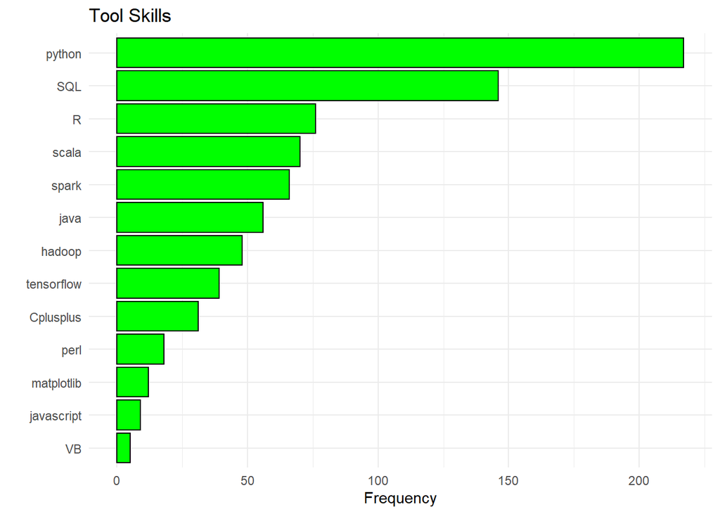

```r
ggplot(toolskills2,aes(x=reorder(variable, value), y=value)) + geom_bar(stat='identity',fill="green",color="black") + xlab('') + ylab('Frequency') + labs(title='Tool Skills') + coord_flip() + theme_minimal()
```

### Frequency of Hard skills

- We repeated the process again here to isolate hard skills most sought after by hiring companies

```r
hardskills <- clean_allcsv %>%
    mutate(machinelearning = grepl("machine learning", Job_Description, ignore.case=TRUE)) %>%
    mutate(modeling = grepl("model", Job_Description, ignore.case=TRUE)) %>%
    mutate(statistics = grepl("statistics", Job_Description, ignore.case=TRUE)) %>%
    mutate(programming = grepl("programming", Job_Description, ignore.case=TRUE)) %>%
    mutate(quantitative = grepl("quantitative", Job_Description, ignore.case=TRUE)) %>%
    mutate(debugging = grepl("debugging", Job_Description, ignore.case=TRUE)) %>%
    mutate(statistical = grepl("statistical",  Job_Description, ignore.case=TRUE)) %>%
    mutate(regression = grepl("regression",  Job_Description, ignore.case=TRUE)) %>%

select(Position, Company, machinelearning, modeling, statistics, programming, quantitative, debugging, statistical, regression)
```

### Setup hard skills for plotting

```r
hardskills2 <- hardskills %>%
               select(-(1:2)) %>%
               summarise_all(sum) %>%
               gather(variable,value) %>%
               arrange(desc(value))
```

### Visualized the most in-demand hard sKills:

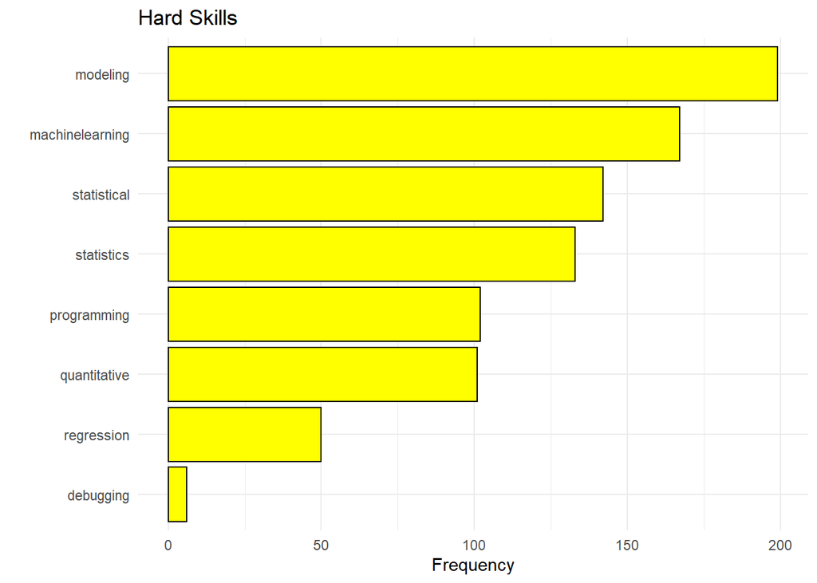

```r
ggplot(hardskills2,aes(x=reorder(variable, value), y=value)) +
  geom_bar(stat='identity',fill="yellow",color="black") +
  xlab('') +
  ylab('Frequency') +
  labs(title='Hard Skills') +
  coord_flip() +
  theme_minimal()
```

### Frequency of Soft skills

- Lastly, We repeated the process to get the soft skills most sought after by hiring companies

```r
softskills <- clean_allcsv %>%
    mutate(workingremote = grepl("working remote", Job_Description, ignore.case=TRUE)) %>%
    mutate(communication = grepl("communication", Job_Description, ignore.case=TRUE)) %>%
    mutate(collaborative = grepl("collaborate", Job_Description, ignore.case=TRUE)) %>%
    mutate(creative = grepl("creative", Job_Description, ignore.case=TRUE)) %>%
    mutate(critical = grepl("critical", Job_Description, ignore.case=TRUE)) %>%
    mutate(problemsolving = grepl("problem solving", Job_Description, ignore.case=TRUE)) %>%
    mutate(activelearning = grepl("active learning", Job_Description, ignore.case=TRUE)) %>%
    mutate(hypothesis = grepl("hypothesis", Job_Description, ignore.case=TRUE)) %>%
    mutate(organized = grepl("organize", Job_Description, ignore.case=TRUE)) %>%
    mutate(judgement = grepl("judgement", Job_Description, ignore.case=TRUE)) %>%
    mutate(selfstarter = grepl("self Starter", Job_Description, ignore.case=TRUE)) %>%
    mutate(interpersonalskills = grepl("interpersonal skills", Job_Description, ignore.case=TRUE)) %>%
    mutate(detail_oriented = grepl("attention to detail", Job_Description, ignore.case=TRUE)) %>%
    mutate(visualization = grepl("visualization", Job_Description, ignore.case=TRUE)) %>%
    mutate(leadership = grepl("leadership", Job_Description, ignore.case=TRUE)) %>%
    mutate(presentation = grepl("presentation", Job_Description, ignore.case=TRUE)) %>%
    mutate(passion = grepl("passion", Job_Description, ignore.case=TRUE)) %>%
    mutate(research = grepl("research", Job_Description, ignore.case=TRUE)) %>%
    mutate(teamwork = grepl("teamwork", Job_Description, ignore.case=TRUE)) %>%
    mutate(integrity = grepl("integrity", Job_Description, ignore.case=TRUE)) %>%
    mutate(passionate= grepl("passionate", Job_Description, ignore.case=TRUE)) %>%
    select(Position, Company, workingremote, communication, collaborative, creative, critical, problemsolving,
  activelearning, hypothesis, organized, judgement, selfstarter, interpersonalskills, detail_oriented,
  visualization, leadership,presentation,passion,research,teamwork,integrity,passionate)
```

### Setup Soft skills for plotting

```r
softskills2 <- softskills %>%
               select(-(1:2)) %>%
               summarise_all(sum) %>%
               gather(variable,value) %>%
               arrange(desc(value))
```

### Visualized the most in-demand soft sKills:

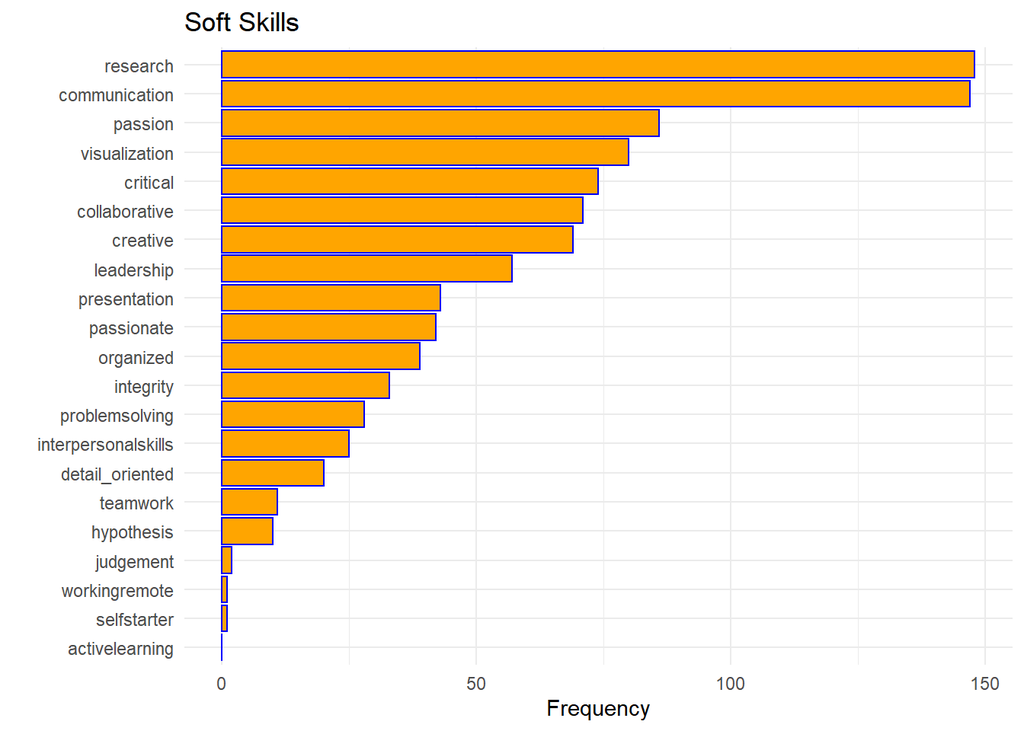

```r
ggplot(softskills2,aes(x=reorder(variable, value), y=value)) + geom_bar(stat='identity',fill="orange",color="blue") + xlab('') + ylab('Frequency') + labs(title='Soft Skills') + coord_flip() + theme_minimal()
```

Observation 2:

- The top 3 technical tool skills associated with data scientist today are: Python, R and SQL
- The top 3 hard skill sets sought by hiring managers are: Modeling, Machine Learning and statistics
- The top soft skills that companies are looking for are: Research, communication which is almost a tie followed

by “passion”.

The 3 top tool and hard skills are very much talked about in our class and the industry whereby by employers

expect their new hires to know already. The tool and hard skill sets are almost pre-requisites with soft skills

as the the added bonus that hiring companies sought.

Hiring companies want their new hires to be able to do 3 things in general:

1. The What: To utilize these tools (Python, R and SQL) on an everyday basisfor thier work.
2. The How: While the tool knowledge is the first step, they also expect their hires to wrap it into a model with

statistics. Modeling machine learning algorithms based on sound statistics are the foundation of a skilled,

competentdata scientist.

3. The Need: The last but not least is “people” or soft skills, the ability for doing sound research and

communicating it to their peers and other business grops is key to a really successful career in data sciene.

We have learned that a good technical person is only as good as his/her communication ability. The ability to

convey technical findings in commmon layman terms is what separates a hire from being a great scientist to simply

just an average one.